# Figure 1 - Definition of the RIG-I-only and STAT-only signatures

Carlos Ramirez

2026-10-27 17:05:38

This markdown reproduces the panels of **Figure 1**. We define two gene signatures that decouple the RIG-I and the IFNR (JAK/STAT) downstream programs using bulk RNA-Seq time courses of A549 cells:

- **IFN time course**: A549 WT cells treated with IFN-β (or control) at several time points.
- **dsRNA time course**: A549 WT and RIG-I KO cells electroporated with dsRNA (or polyC / mock control) at several time points.

Dynamically regulated genes were inferred with a splines approach in each time course (Aleksandr Refeld pipeline). Genes that are dynamic in the RIG-I KO (i.e. IFN-driven secondary response) or after IFN treatment are compared, the shared genes are removed and the remaining genes are used for a concatenated PCA of the IFN and RIG-I KO samples. PC1 separates the RIG-I-driven samples and PC2 the IFN-driven samples; the top-100 genes of the PC1 loadings define the **RIG-I-only** signature and the bottom-100 of the PC2 loadings the **STAT-only** (IFN-only) signature. The signatures are validated by scoring single A549 cells treated with dsRNA/IFN and A549 cells infected with influenza A virus (Sun et al. 2020).

Panels:

| Panel | File (`figures/figure_01/`) |
| --- | --- |
| Venn diagram IFN vs RIG-I KO dynamic genes | `venn_diagram_ko_ifn_aleksandr_genes.pdf` |
| Heatmap of the dynamic genes (IFN + RIG-I KO samples) | `heatmap_concatenated_subset_mtx.pdf` |
| Concatenated PCA (IFN + RIG-I KO samples) | `pca_concatenated_aleksandr_ko_ifn_genes_noWT.pdf` |
| Scoring of the A549 scRNA-Seq data | `scoring_ifn_rig_ionly_signatures.pdf` |
| RIG-I-only vs STAT-only scores in IAV infected A549 (Sun et al.) | `scatterplot_scores_rigi_stat_viralgo.pdf` |

Outputs written to `analysis/figure_01/` are re-used by other sections:

- `rigi_vs_stat_only_signatures.rds` / `.xlsx`: final signatures (used by every other figure through `path2signs` in `settings.R`).
- `pca_concatenated.rds`: concatenated PCA (used by Supplementary Figure 1 to project the WT samples).

# Input data

[output not shown]

Original scripts: `interferon_model/scripts/R/july_2026/01_rigi_stat_only_signatures_definition.Rmd`, `interferon_model/scripts/R/april_2026/figure_01_dsRNA_epo_description_noWT.Rmd`, `interferon_model/scripts/R/july_2026/01_scRNASeq_projections_Sun.Rmd`.

```r
library(ggplot2)
library(dplyr)
library(readr)
library(ggrepel)
library(ComplexHeatmap)
library(circlize)
library(viridis)
library(ggVennDiagram)
library(purrr)
library(scales)
library(patchwork)
library(Seurat)

source('/media/bq-storage/ag-cherrmann/cramirez/decoupling_rigi_ifn/scripts/R/settings.R')
```

## Initial settings

```r
dirs <- section_dirs("figure_01")
path2figures <- dirs$figures
path2analysis <- dirs$analysis

knitr::opts_chunk$set(
  message = FALSE,
  warning = FALSE,
  error = FALSE
)
```

# Loading the IFN signature

Dynamically regulated genes after IFN-β treatment, inferred with the splines approach in `00_ifn_dynamical_genes.R` (IFN treated vs control samples).

```r
ifn_set <- readRDS(file.path(path2project,
                             'analysis/2026_May/IFNb_Response_Omnibus_Strict_FCcorresp.rds'))
length(ifn_set)
```

```
## [1] 196
```

# Loading the dsRNA RIG-I KO signature

Dynamically regulated genes after dsRNA electroporation in RIG-I KO cells, inferred with the same approach (`00_EPO_dynamical_genes.R`).

```r
dsRNA_set <- readRDS(file.path(path2project,
                               'analysis/2026_May/wt_ko_splines_gene_sets.rds'))
ko_set <- dsRNA_set$ko
length(ko_set)
```

```
## [1] 1183
```

# Loading IFN treated samples data

In-house bulk RNA-Seq data of A549 cells treated with IFN at different time points. We use VST transformed values. The `dsRNA-16h` sample is removed.

```r
path2ifn <- file.path(path2project, "analysis/01_QC_visualization")
ifn_df <- read_tsv(file.path(path2ifn, 'vst_interferon_RNASeq.tsv.gz'),
                   show_col_types = FALSE) %>%
                as.data.frame()
colnames(ifn_df) <- gsub('raw_counts_', '', colnames(ifn_df))

## Removing dsRNA 16 hours
ifn_df <- ifn_df[, colnames(ifn_df) != 'dsRNA-16h']

ifn_ensembl_ids <- ifn_df$ensemb_id
ifn_mtx <- dplyr::select(ifn_df, -ensemb_id) %>%
                as.matrix()
rownames(ifn_mtx) <- ifn_ensembl_ids

dim(ifn_mtx)
```

```
## [1] 60623    19
```

```r
colnames(ifn_mtx)
```

```
##  [1] "control-12h"  "control-16h"  "control-24h"  "control-2h"   "control-48h"
##  [6] "control-4h"   "control-6h"   "control-72h"  "control-8h"   "control-8h-a"
## [11] "IFN-12h"      "IFN-16h"      "IFN-24h"      "IFN-2h"       "IFN-48h"
## [16] "IFN-4h"       "IFN-6h"       "IFN-72h"      "IFN-8h"
```

# Loading dsRNA electroporated samples data

VST values of the WT and RIG-I KO dsRNA time course. The columns `gene_name` and `ensembl_id` are used as gene annotation. Sample names encode `<genotype>_<condition>-<time>h`.

```r
path2vst_dsRNA <- "/media/ag-cherrmann/cramirez/rnaSeq_dsRNA/analysis/sept_2025/01_exploratory_data_analysis/vst_dsRNA_sept2025.tsv.gz"
gex <- readr::read_tsv(path2vst_dsRNA, show_col_types = FALSE) %>%
              as.data.frame()

colnames(gex) <- gsub('raw_counts_|_featureCounts.tsv',
                      '', colnames(gex))

gene_anns <- dplyr::select(gex, gene_name, ensembl_id)

rownames(gex) <- gex$ensembl_id

## RIG-I KO samples only
epo_gex <- gex[,grepl('KO|gene_name|ensembl_id',
                      colnames(gex))]
head(epo_gex, 2)
```

```
##                 KO_control-16h KO_control-2h KO_control-48h KO_dsRNA-12h
## ENSG00000223972       4.424220      4.904234       4.424220     4.424220
## ENSG00000227232       5.839217      5.702625       5.797048     6.994042
##                 KO_dsRNA-16h KO_dsRNA-24h KO_dsRNA-2h KO_dsRNA-48h KO_dsRNA-4h
## ENSG00000223972     4.751982     4.424220    4.424220     4.424220    4.424220
## ENSG00000227232     7.364458     6.613901    6.350205     6.205123    6.999349
##                 KO_dsRNA-6h KO_dsRNA-72h KO_dsRNA-8h KO_polyC-12h KO_polyC-16h
## ENSG00000223972    4.424220     4.965824    4.424220     4.424220     4.711424
## ENSG00000227232    7.453949     6.197644    6.140588     5.805306     6.121228
##                 KO_polyC-24h KO_polyC-2h KO_polyC-48h KO_polyC-4h KO_polyC-6h
## ENSG00000223972     4.797305    4.845790     4.707221    4.860640     4.42422
## ENSG00000227232     6.199346    5.687468     6.227083    5.287456     6.09894
##                 KO_polyC-72h KO_polyC-8h gene_name      ensembl_id
## ENSG00000223972     5.094226    4.756562   DDX11L1 ENSG00000223972
## ENSG00000227232     5.805016    5.404486    WASH7P ENSG00000227232
```

# Venn diagram (Figure 1)

Intersection of the IFN and RIG-I KO dynamic genes. The gene sets are also exported as a table.

```r
gene_sets <- list(
  IFN = ifn_set,
  KO  = ko_set
)

gene_sets_list <- lapply(gene_sets,
                         function(gene_set){
                                 data.frame(ensembl_id=gene_set)
})
gene_sets_list <- lapply(gene_sets_list,
                         function(df){
                                 mutate(df,
                                        gene_symbol=plyr::mapvalues(
                                                x = ensembl_id,
                                                from = gene_anns$ensembl_id,
                                                to = gene_anns$gene_name,
                                                warn_missing = FALSE
                                        ))
                         })
lapply(gene_sets_list, dim)
```

```
## $IFN
## [1] 196   2
##
## $KO
## [1] 1183    2
```

```r
writexl::write_xlsx(
        gene_sets_list,
        file.path(path2analysis, 'gene_sets_venn_diagram.xlsx')
)

p <- ggVennDiagram(
  gene_sets,
  label = "count"
) +
  scale_fill_gradient(low = "grey90", high = "grey30") +
  theme_void() +
  theme(
    legend.position = "none",
    text = element_text(size = 12)
  )

pdf(file.path(path2figures, 'venn_diagram_ko_ifn_aleksandr_genes.pdf'),
    height=3, width=3)
p
dev.off()
```

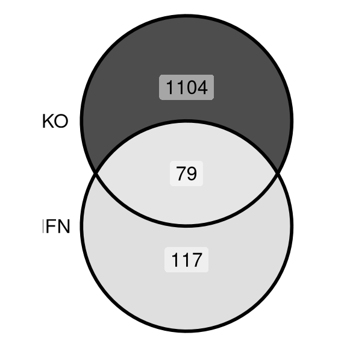

```r
p
```

## Extracting RIG-I-only, IFN-only and shared genes

```r
## Genes only in the IFN set
ifn_only <- setdiff(ifn_set, ko_set)

## Genes only in the RIG-I KO set
rigi_only <- setdiff(ko_set, ifn_set)

## Genes shared by both sets
shared_genes <- intersect(ifn_set, ko_set)

sapply(list(ifn_only=ifn_only,
            rigi_only=rigi_only,
            shared_genes=shared_genes),
       length)
```

```
##     ifn_only    rigi_only shared_genes
##          117         1104           79
```

# Heatmap of the dynamic genes (Figure 1)

Heatmap of the union of RIG-I KO and IFN dynamic genes across the RIG-I KO dsRNA time course and the IFN time course (row-scaled VST values). Genes are split by membership (KO only, IFN only, both).

The original analysis loaded the gene sets from the files below. They contain exactly the same genes as the sets loaded above (checked here); we keep them so that the gene order (and hence the row clustering) is identical to the published panel.

```r
ifn_clusters_df <- readxl::read_xlsx(
        file.path(path2project,
                  'analysis/figure_00_genes_clusters_inference_IFN_aleksandr',
                  'mfuzz_results_interferon_rf_splines_aleksandr.xlsx')
        )
ifn_genes_ids <- ifn_clusters_df$Gene

dsRNA_set_hm <- readRDS(file.path(path2project,
                                  'data/aleksandr_genes/wt_ko_splines_gene_sets.rds'))

stopifnot(setequal(ifn_genes_ids, ifn_set),
          setequal(dsRNA_set_hm$ko, ko_set))

selected_genes <- c(dsRNA_set_hm$ko, ifn_genes_ids)
length(unique(selected_genes))
```

```
## [1] 1300
```

Concatenating the dsRNA and IFN matrices.

```r
shared_genes1 <- intersect(selected_genes, rownames(ifn_mtx))
shared_genes2 <- intersect(shared_genes1, gex$ensembl_id)

epo_mtx <- dplyr::select(gex, `KO_control-16h`:`WT_polyC-8h`)
rownames(epo_mtx) <- gex$ensembl_id
concatenated_hm_mtx <- cbind(epo_mtx[shared_genes2,],
                             ifn_mtx[shared_genes2,]) %>%
                        as.matrix()
dim(concatenated_hm_mtx)
```

```
## [1] 1300   61
```

Sample annotations are parsed from the sample names.

```r
samples <- colnames(concatenated_hm_mtx)

sample_anno <- data.frame(
  sample = samples,
  stringsAsFactors = FALSE
)

sample_anno$phenotype <- ifelse(grepl("^KO_", samples), "KO",
                         ifelse(grepl("^WT_", samples), "WT", "WT_IFN"))

sample_anno$condition <- ifelse(grepl("control", samples), "control",
                         ifelse(grepl("dsRNA", samples), "dsRNA",
                         ifelse(grepl("polyC", samples), "polyC",
                         ifelse(grepl("IFN", samples), "IFN", NA))))

sample_anno$time <- as.numeric(sub(".*-(\\d+)h.*", "\\1", samples))

sample_anno$time_discrete <- factor(
  sample_anno$time,
  levels = sort(unique(sample_anno$time)),
  ordered = TRUE
)
rownames(sample_anno) <- sample_anno$sample
```

Removing the WT dsRNA samples, ordering the samples and drawing the heatmap.

```r
## colours specific to this panel
heatmap_condition_colors <- c("control"="#8DA0CB",
                              "IFN"="#F98E3D",
                              "dsRNA"='#A6D854',
                              "polyC"='#66C2A5')

harmonized_colors <- c(
  "0"   = "#01665E",
  "1"   = "#247968",
  "2"   = "#408772",
  "4"   = "#5D977C",
  "6"   = "#7BA790",
  "8"   = "#9BB79E",
  "12"  = "#B8C7A9",
  "16"  = "#D0B88E",
  "24"  = "#DBB993",
  "48"  = "#C18A63",
  "72"  = "#A65B33",
  "96"  = "#8C2D04"
)

phenotype_colors <- c(WT='red',
                      WT_IFN='red',
                      KO='steelblue')

selected_samples <- grep('WT',
                         colnames(concatenated_hm_mtx),
                         invert = TRUE,
                         value = TRUE)

concatenated_subset_mtx <- concatenated_hm_mtx[,selected_samples]
sample_subset_anno <- sample_anno[selected_samples,]

phenotype_levels <- c("WT", "KO", "WT_IFN")
condition_levels <- c("dsRNA", "IFN", "polyC", "control")

sample_subset_anno$phenotype <- factor(sample_subset_anno$phenotype,
                                       levels = phenotype_levels)
sample_subset_anno$condition <- factor(sample_subset_anno$condition,
                                       levels = condition_levels)
sample_subset_anno$time_discrete <- factor(
  sample_subset_anno$time_discrete,
  levels = sort(unique(as.numeric(as.character(sample_subset_anno$time_discrete)))),
  ordered = TRUE
)

sample_order <- order(
  sample_subset_anno$phenotype,
  sample_subset_anno$condition,
  sample_subset_anno$time_discrete
)

sample_subset_anno <- sample_subset_anno[sample_order, ]
concatenated_subset_mtx <- concatenated_subset_mtx[, sample_subset_anno$sample]

concatenated_subset_mtx_scaled <- t(scale(t(concatenated_subset_mtx)))

## Column annotation
ha_col <- HeatmapAnnotation(
  Phenotype = sample_subset_anno$phenotype,
  Condition = sample_subset_anno$condition,
  Time = sample_subset_anno$time_discrete,
  col = list(
    Phenotype = phenotype_colors,
    Condition = heatmap_condition_colors,
    Time = harmonized_colors
  ),
  annotation_name_side = "left",
  show_annotation_name = TRUE
)

col_fun <- colorRamp2(
  c(min(concatenated_subset_mtx_scaled),
    0, max(concatenated_subset_mtx_scaled)),
  c("#2166AC", "white", "#B2182B")
)

## Row annotation: gene set membership
signatures_list <- list(ko=dsRNA_set_hm$ko,
                        ifn=ifn_genes_ids)

genes <- rownames(concatenated_subset_mtx)
gene_category <- ifelse(
  genes %in% signatures_list$ko & genes %in% signatures_list$ifn, "both",
  ifelse(
    genes %in% signatures_list$ko, "ko",
    ifelse(
      genes %in% signatures_list$ifn, "ifn",
      "none"
    )
  )
)
gene_category <- factor(
  gene_category,
  levels = c("ko", "ifn", "both", "none")
)

gene_category_colors <- c(
  ko = "#1b9e77",
  ifn = "#d95f02",
  both = "#7570b3",
  none = "grey80"
)

ha_row <- rowAnnotation(
  Signature = gene_category,
  col = list(Signature = gene_category_colors),
  show_annotation_name = TRUE
)

hm <- Heatmap(
  concatenated_subset_mtx_scaled,
  name = "Signal",
  col = col_fun,
  top_annotation = ha_col,
  left_annotation = ha_row,

  show_row_names = FALSE,
  show_column_names = FALSE,

  cluster_rows = TRUE,
  cluster_columns = FALSE,

  row_split = gene_category
)

pdf(file.path(path2figures, "heatmap_concatenated_subset_mtx.pdf"),
     width=6, height=4)
draw(hm)
dev.off()
```

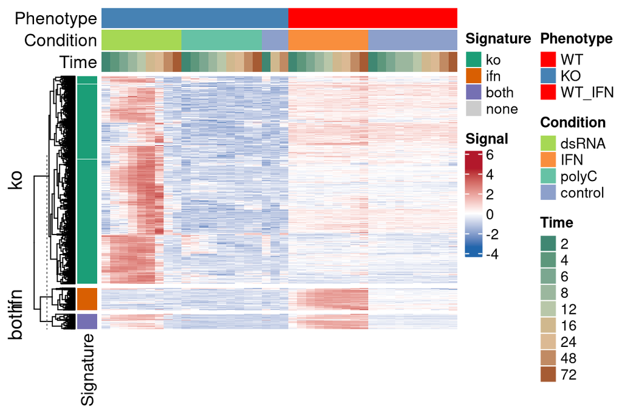

```r
hm
```

# Concatenated PCA (IFN + RIG-I KO) (Figure 1)

For the PCA we remove the shared genes in order to remove the common signal and isolate the RIG-I-only and IFN-only programs. VST values of the IFN and RIG-I KO samples are concatenated.

```r
concatenated_genes <- unique(c(ifn_only, rigi_only))
length(concatenated_genes)
```

```
## [1] 1221
```

```r
## dsRNA RIG-I KO matrix
epo_mtx_subset <- dplyr::select(epo_gex, -gene_name, -ensembl_id)
epo_mtx_subset <- epo_mtx_subset[concatenated_genes, ]

## IFN matrix
ifn_mtx_subset <- ifn_mtx[concatenated_genes, ]

intersected_genes <- intersect(rownames(ifn_mtx_subset),
                               rownames(epo_mtx_subset))

concatenated_mtx <- cbind(ifn_mtx_subset[intersected_genes,],
                          epo_mtx_subset[intersected_genes,])
dim(concatenated_mtx)
```

```
## [1] 1221   40
```

```r
pca_concatenated <- prcomp(t(concatenated_mtx),
                           center = TRUE,
                           retx = TRUE,
                           rank. = 10)

projection_df <- pca_concatenated$x %>%
                      as.data.frame()

samples_annotations_df <- data.frame(
  sample = rownames(projection_df),
  stringsAsFactors = FALSE
) |>
  dplyr::mutate(
    genotype = dplyr::case_when(
      stringr::str_detect(sample, "KO") ~ "KO",
      stringr::str_detect(sample, "WT")  ~ "WT",
      .default = 'IFN'
    ),
    condition = dplyr::case_when(
      stringr::str_detect(sample, "control") ~ "control",
      stringr::str_detect(sample, "IFN")     ~ "IFN",
      stringr::str_detect(sample, "polyC")   ~ "polyC",
      stringr::str_detect(sample, "dsRNA")   ~ "dsRNA",
      TRUE ~ NA_character_
    ),
    time = stringr::str_extract(sample, "\\d+(?=h)") |> as.numeric()
  )
```

```r
stopifnot(all(rownames(projection_df) == samples_annotations_df$sample))
projection_annotated_df <- cbind(projection_df,
                                 samples_annotations_df)

explained_var <- (pca_concatenated$sdev^2) /
                      sum(pca_concatenated$sdev^2) * 100

pc1_var <- round(explained_var[1], 1)
pc2_var <- round(explained_var[2], 1)

pc12_projection <- projection_annotated_df %>%
  ggplot(aes(
    PC1, PC2,
    colour = genotype,
    shape  = condition,
    label  = time
  )) +
  geom_point(size=4) +
  geom_text_repel(size = 6) +
  scale_colour_manual(
    values = c(WT = "red", KO = "steelblue", IFN = "forestgreen")
  ) +
  scale_x_continuous(breaks = scales::pretty_breaks(n = 3)) +
  scale_y_continuous(breaks = scales::pretty_breaks(n = 3)) +
  labs(
    x = paste0("PC1 (", pc1_var, "% variance)"),
    y = paste0("PC2 (", pc2_var, "% variance)")
  ) +
  theme_classic() +
  theme(
    axis.text  = element_text(size = 16),
    axis.title = element_text(size = 18)
  )

pdf(file.path(path2figures, 'pca_concatenated_aleksandr_ko_ifn_genes_noWT.pdf'),
    width=6, height=5)
pc12_projection
dev.off()
```

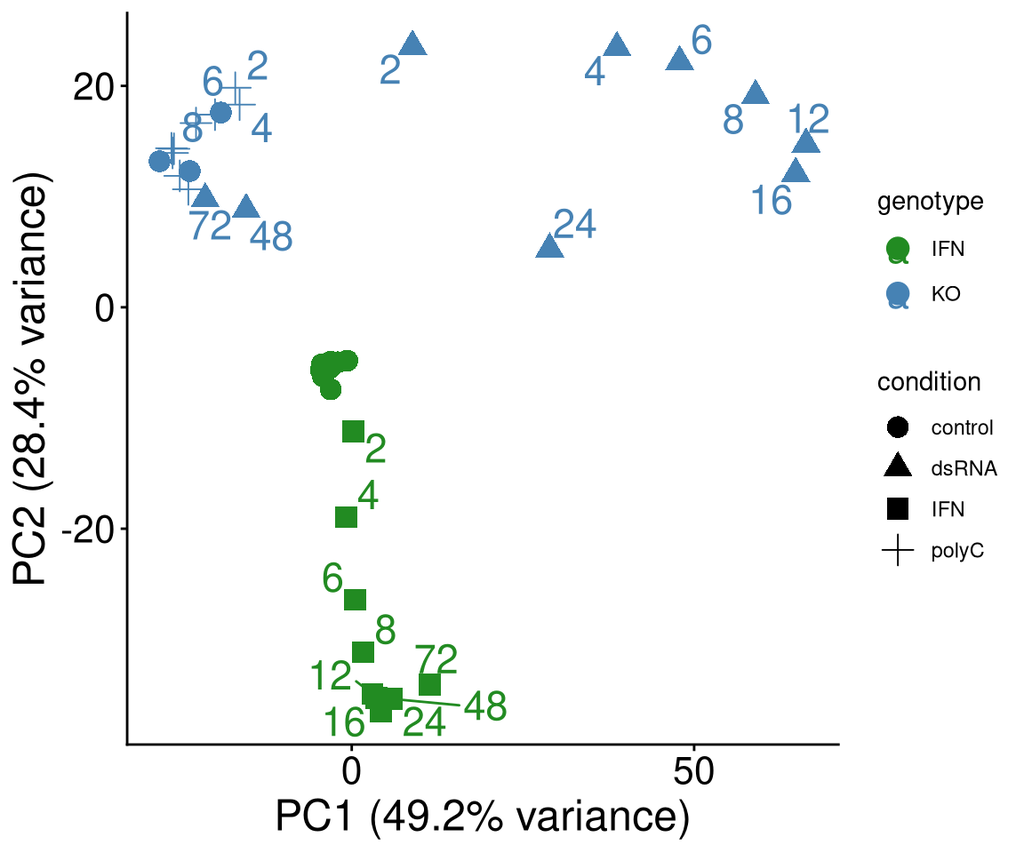

```r
pc12_projection
```

The PCA is saved so that Supplementary Figure 1 can project the WT samples onto it.

```r
saveRDS(list(pca = pca_concatenated,
             intersected_genes = intersected_genes,
             pc1_var = pc1_var,
             pc2_var = pc2_var),
        file.path(path2analysis, 'pca_concatenated.rds'))
```

# Defining the RIG-I-only and STAT-only signatures

Genes are ranked by their PC1 and PC2 loadings (Ensembl IDs converted to gene symbols). The RIG-I-only signature is the top-100 genes of PC1 and the STAT-only signature the bottom-100 genes of PC2. Interferon genes and OASL are removed from both signatures.

```r
pc1 <- pca_concatenated$rotation %>%
        as.data.frame() %>%
               dplyr::arrange(desc(PC1)) %>%
                dplyr::select(PC1)

pc2 <- pca_concatenated$rotation %>%
        as.data.frame() %>%
               dplyr::arrange(desc(PC2)) %>%
                dplyr::select(PC2)

pc_signatures <- list(pc1=pc1,
                      pc2=pc2)

## Ensembl ID to gene symbol
pc_signatures_gs <- lapply(pc_signatures,
                           function(genes_df){
                                   gene_names <- plyr::mapvalues(
                                           x = rownames(genes_df),
                                           from = gene_anns$ensembl_id,
                                           to = gene_anns$gene_name,
                                           warn_missing = FALSE
                                   )
                                   genes_df$'gene_symbol' <- gene_names
                                   genes_df$'ensembl_id' <- rownames(genes_df)
                                   genes_df <- genes_df[!duplicated(genes_df$gene_symbol),]
                                   rownames(genes_df) <- genes_df$gene_symbol
                                   genes_df
                           })

pc_ranks <- lapply(pc_signatures_gs, function(df) {
  v <- df[[1]]
  names(v) <- rownames(df)
  sort(v, decreasing = TRUE)
})

rigi_only_sign <- pc_ranks$pc1 %>%
                   head(100) %>%
                   names

stat_only_sign <- pc_ranks$pc2 %>%
                   tail(100) %>%
                   names

signatures_gene_symbol <- list(rigi_only=rigi_only_sign,
                               stat_only=stat_only_sign)

signatures_gene_symbol <- lapply(signatures_gene_symbol,
                                 function(genes){
                                         grep('IFN|OASL', genes,
                                              value = TRUE,
                                              invert = TRUE)
                                 })
sapply(signatures_gene_symbol, length)
```

```
## rigi_only stat_only
##        94        99
```

The signatures are saved and used by all other sections (`path2signs` in `settings.R`). We check that they are identical to the signatures used in the original analysis.

```r
signatures_gene_symbol_df <- lapply(signatures_gene_symbol,
                                    function(genes){
                                            data.frame(gene_symbol = genes)
                                    })
writexl::write_xlsx(
        x = signatures_gene_symbol_df,
        path = file.path(path2analysis, 'rigi_vs_stat_only_signatures.xlsx')
)
saveRDS(signatures_gene_symbol, path2signs, compress = TRUE)

original_signatures <- readRDS(file.path(path2project,
                                         'analysis/2026_May/rigi_vs_stat_only_signatures.rds'))
identical(original_signatures, signatures_gene_symbol)
```

```
## [1] TRUE
```

# Scoring the A549 scRNA-Seq data (Figure 1)

In-house scRNA-Seq data of A549 cells electroporated with dsRNA or polyC (3 and 16 hours), with or without IFN priming. Cells are scored with the signatures using `AddModuleScore`.

```r
path2a549_sc <- "/media/ag-cherrmann/cramirez/multiome_ifn_project/data/seurat/ifn_treated_cells_rnaseq_processed_seurat.rds"
a549_cells <- readRDS(path2a549_sc)
table(a549_cells$orig.ident)
```

```
##
## 3_16h_-IFN_dsRNA  4_3h_pIFN_dsRNA  5_3h_pIFN_polyC  6_3h_-IFN_dsRNA
##              110              105              523              102
##  7_3h_-IFN_polyC
##               60
```

```r
umap_plot <- DimPlot(a549_cells,
        pt.size = 2.5,
        alpha = 0.5,
        label = TRUE)
```

```r
a549_cells <- AddModuleScore(a549_cells,
                           features = signatures_gene_symbol,
                           name = names(signatures_gene_symbol))

ref_line_size <- 0.8

scores_plot <- a549_cells@meta.data %>%
  ggplot(aes(
    x = rigi_only1,
    y = stat_only2,
    colour = orig.ident
  )) +
  stat_ellipse(
    aes(group = orig.ident),
    type = "norm",
    level = 0.68,
    linewidth = 1
  ) +
  geom_hline(
    yintercept = 0,
    linetype = "dashed",
    colour = "gray30",
    linewidth = ref_line_size
  ) +
  geom_vline(
    xintercept = 0,
    linetype = "dashed",
    colour = "gray30",
    linewidth = ref_line_size
  ) +
  geom_abline(
    intercept = 0,
    slope = 1,
    linetype = "dashed",
    colour = "gray30",
    linewidth = ref_line_size
  ) +
  geom_point(size = 1.6, alpha = 0.5) +
  scale_x_continuous(breaks = pretty_breaks(n = 3)) +
  scale_y_continuous(breaks = pretty_breaks(n = 3)) +
  labs(
    x = "RIGI–only signature",
    y = "IFN-only signature",
    colour = "Sample"
  ) +
  theme_classic() +
  theme(
    axis.title = element_text(size = 14),
    axis.text  = element_text(size = 12),
    legend.title = element_text(size = 12),
    legend.text  = element_text(size = 11)
  )

pdf(file.path(path2figures, 'scoring_ifn_rig_ionly_signatures.pdf'),
    width=12, height=4.5)
gridExtra::grid.arrange(umap_plot, scores_plot, ncol = 2)
dev.off()
```

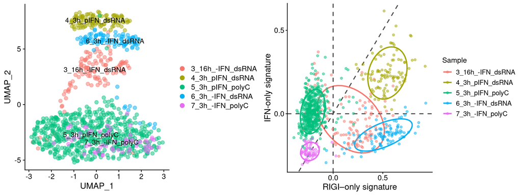

```r
gridExtra::grid.arrange(umap_plot, scores_plot, ncol = 2)
```

# Influenza A infected A549 cells (Sun et al. 2020) (Figure 1)

scRNA-Seq of A549 cells infected with influenza A virus (A/Perth/16/2009, GSE143167). Libraries are mock, bystander and infected cells; the expression of the viral NA segment (gene `NA`) is used as a proxy of viral load.

## Processing (not run)

The raw cellranger output was processed as follows and saved as a Seurat object, which is loaded in the next chunk. The viral gene `NA` was renamed to `NA_vir` in the features file to avoid it being read as a missing value.

```r
library(DropletUtils)
library(scran)
path2sun <- '/media/bq-storage/ag-cherrmann/cramirez/data/GSE143167_cellranger_hg38_perth09/'

sce <- read10xCounts(path2sun, col.names=TRUE)
e.out <- emptyDrops(counts(sce))
sce <- sce[,which(e.out$FDR <= 0.001)]

rownames(sce) <- uniquifyFeatureNames(rowData(sce)$ID, rowData(sce)$Symbol)
rownames(sce)[rownames(sce) %in% "NA_vir"] <- "NA"

Lib.ID <- strsplit(sce$Barcode, "-") %>% sapply(function(x) x[2]) %>% factor
levels(Lib.ID) <- c("Bystander","Mock","Infected")
sce$Library <- factor(Lib.ID, levels = c("Mock","Bystander","Infected"))

sun_seurat <- CreateSeuratObject(counts = counts(sce),
                                 project = "Sun_scRNA",
                                 min.features = 0,
                                 min.cells = 0)
sun_seurat$'library' <- sce$Library

sun_seurat <- subset(sun_seurat, nCount_RNA > 20000 )
sun_seurat <- NormalizeData(sun_seurat)
sun_seurat <- FindVariableFeatures(sun_seurat)
sun_seurat <- ScaleData(sun_seurat)
sun_seurat <- RunPCA(sun_seurat)
sun_seurat <- RunUMAP(sun_seurat, dims = 1:45)

saveRDS(sun_seurat,
        file = paste0(path2sun, '/sun_2020_processed_seurat.rds'))
```

```r
path2sun <- '/media/bq-storage/ag-cherrmann/cramirez/data/GSE143167_cellranger_hg38_perth09/'
sun_seurat <- readRDS(file.path(path2sun, 'sun_2020_processed_seurat.rds'))
table(sun_seurat$library)
```

```
##
##      Mock Bystander  Infected
##      2821      2126      1535
```

## Scoring cells

Cells are scored with the RIG-I-only and STAT-only signatures together with the MSigDB gene sets “response to virus”, “interferon gamma response” and “response to interferon beta” (interferon genes removed from all sets). The scores were computed when the object was created (May 2026) and are stored in its metadata (`stat_only1`, `rigi_only2`, `viral_go3`, …).

As a check, the cells are re-scored here with the final signatures and the current MSigDB gene sets, in the same gene set order. The RIG-I-only and STAT-only scores are identical to the stored ones (r = 1). The response-to-virus score is slightly different (r ~ 0.97) because MSigDB has updated the GOBP_RESPONSE_TO_VIRUS gene set since. The panel is therefore drawn with the stored scores, which reproduces the published figure.

```r
download_msigdb <- function(gene_set){
        url <- paste0('https://www.gsea-msigdb.org/gsea/msigdb/human/download_geneset.jsp?geneSetName=',
                      gene_set, '&fileType=grp')
        genes <- readLines(url)
        genes[3:length(genes)]
}

viral_go <- download_msigdb('GOBP_RESPONSE_TO_VIRUS')
ifnl_go <- download_msigdb('HALLMARK_INTERFERON_GAMMA_RESPONSE')
ifnb_go <- download_msigdb('GOBP_RESPONSE_TO_INTERFERON_BETA')

signatures_sun <- list(stat_only=signatures_gene_symbol$stat_only,
                       rigi_only=signatures_gene_symbol$rigi_only,
                       viral_go=viral_go,
                       ifnl_go=ifnl_go,
                       ifnb_go=ifnb_go)
signatures_sun <- lapply(signatures_sun,
                         function(genes){
                                 grep(pattern = 'IFN', genes, value = TRUE,
                                      invert = TRUE)
                         })
sapply(signatures_sun, length)
```

```
## stat_only rigi_only  viral_go   ifnl_go   ifnb_go
##        99        94       352       199        31
```

```r
## scores stored in the processed object (used for the panel)
stored_scores <- FetchData(sun_seurat,
                           vars = c('stat_only1', 'rigi_only2', 'viral_go3'))

score_columns <- paste0(names(signatures_sun), seq_along(signatures_sun))
sun_rescored <- sun_seurat
sun_rescored@meta.data <- sun_rescored@meta.data[, ! colnames(sun_rescored@meta.data) %in%
                                                     score_columns]
sun_rescored <- AddModuleScore(
  object = sun_rescored,
  features = signatures_sun,
  name = names(signatures_sun)
)

## agreement with the stored scores
sapply(colnames(stored_scores),
       function(x) cor(stored_scores[[x]], sun_rescored@meta.data[[x]]))
```

```
## stat_only1 rigi_only2  viral_go3
##  1.0000000  1.0000000  0.9739382
```

```r
rm(sun_rescored)
```

## RIG-I-only and STAT-only scores vs viral load

Top: RIG-I-only vs STAT-only score; bottom: response-to-virus GO score vs STAT-only score. Cells are coloured by the expression of the viral NA segment and a linear model is fitted per library.

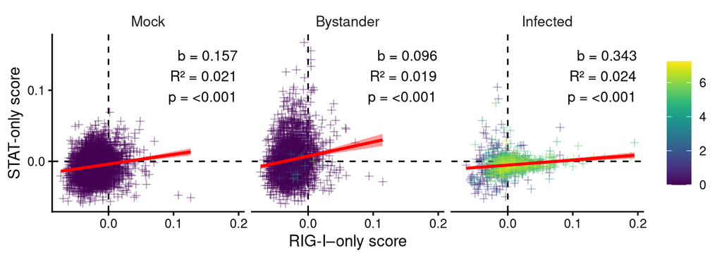

```r
md <- FetchData(sun_seurat, vars = c('NA',
                                     'stat_only1',
                                     'rigi_only2',
                                     'viral_go3',
                                     'library'))
md$'viral_expression' <- md$`NA`

## Linear model per library: RIG-I-only ~ STAT-only
lm_stats <- md %>%
  group_by(library) %>%
  do({
    model <- lm(rigi_only2 ~ stat_only1, data = .)
    broom::tidy(model) %>%
      filter(term == "stat_only1") %>%
      mutate(
        r2 = summary(model)$r.squared
      )
  }) %>%
  ungroup() %>%
  mutate(
    label = paste0(
      "b = ", round(estimate, 3),
      "\nR² = ", round(r2, 3),
      "\np = ", format.pval(p.value, digits = 3, eps = 0.001)
    )
  )

p1 <- md %>%
  dplyr::arrange(viral_expression) %>%
  ggplot(aes(
    x = rigi_only2,
    y = stat_only1,
    colour = viral_expression
  )) +
  geom_hline(yintercept = 0, linetype = "dashed", color = "black") +
  geom_vline(xintercept = 0, linetype = "dashed", color = "black") +
  geom_point(shape = 3, alpha = 0.4) +
  geom_smooth(method = "lm", se = TRUE, color = "red", fill = "red") +
  geom_text(
    data = lm_stats,
    aes(x = Inf, y = Inf, label = label),
    inherit.aes = FALSE,
    hjust = 1.1,
    vjust = 1.3,
    color = "black",
    size = 3.5
  ) +
  scale_x_continuous(
    name = "RIG-I–only score",
    breaks = scales::pretty_breaks(n = 3)
  ) +
  scale_y_continuous(
    name = "STAT-only score",
    breaks = scales::pretty_breaks(n = 3)
  ) +
  theme_classic() +
  theme(
    legend.title = element_blank(),
    strip.background = element_blank(),
    strip.text = element_text(size = 10)
  ) +
  facet_wrap(~library) +
  scale_colour_viridis()

p1
```

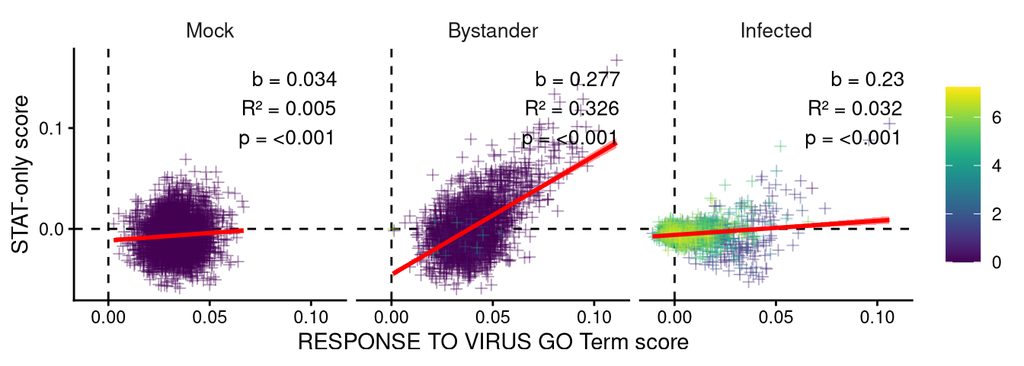

```r
## Linear model per library: viral GO ~ STAT-only
lm_stats <- md %>%
  group_by(library) %>%
  do({
    model <- lm(viral_go3 ~ stat_only1, data = .)
    broom::tidy(model) %>%
      filter(term == "stat_only1") %>%
      mutate(
        r2 = summary(model)$r.squared
      )
  }) %>%
  ungroup() %>%
  mutate(
    label = paste0(
      "b = ", round(estimate, 3),
      "\nR² = ", round(r2, 3),
      "\np = ", format.pval(p.value, digits = 3, eps = 0.001)
    )
  )

p2 <- md %>%
  dplyr::arrange(viral_expression) %>%
  ggplot(aes(
    x = viral_go3,
    y = stat_only1,
    colour = viral_expression
  )) +
  geom_hline(yintercept = 0, linetype = "dashed", color = "black") +
  geom_vline(xintercept = 0, linetype = "dashed", color = "black") +
  geom_point(shape = 3, alpha = 0.4) +
  geom_smooth(method = "lm", se = TRUE, color = "red", fill = "red") +
  geom_text(
    data = lm_stats,
    aes(x = Inf, y = Inf, label = label),
    inherit.aes = FALSE,
    hjust = 1.1,
    vjust = 1.3,
    color = "black",
    size = 3.5
  ) +
  scale_x_continuous(
    name = "RESPONSE TO VIRUS GO Term score",
    breaks = scales::pretty_breaks(n = 3)
  ) +
  scale_y_continuous(
    name = "STAT-only score",
    breaks = scales::pretty_breaks(n = 3)
  ) +
  theme_classic() +
  theme(
    legend.title = element_blank(),
    strip.background = element_blank(),
    strip.text = element_text(size = 10)
  ) +
  facet_wrap(~library) +
  scale_colour_viridis()

p2
```

```r
pdf(file.path(path2figures, "scatterplot_scores_rigi_stat_viralgo.pdf"),
    width=5, height=3.5)
p1 / p2
dev.off()
```

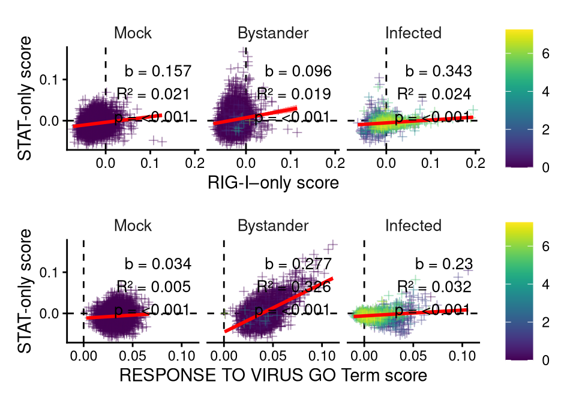

```r
p1 / p2
```